# Coursework Report

*N* removed NAs: 2

*N* removed <18: 21

*N* total clean: 124

| Group | *N* | *M*<sub>age</sub> | *M*<sub>rating</sub> |
| --- | --- | --- | --- |
| Control | 65 | 20.7 | 5.94 |
| Experim | 59 | 20.7 | 6.92 |

**Main analysis results**

*t*(122) = -7.65, *p* < .001

# Coursework Report

Analysing Data, Spring 2020

# Methods

## Participants

Table 1. *Descriptive statistics by condition*

| Condition | *N* | % | *M*<sub>age</sub> | *SD*<sub>age</sub> |
| --- | --- | --- | --- | --- |
| control | 65 | 52.4 | 20.7 | 1.61 |
| experimental | 59 | 47.6 | 20.7 | 1.85 |

## Design

In this study, we will be investigating the hypothesis: ‘Does colour influence attractiveness?’. In order to investigate this, we will use an independent-measures design, where participants are allocated to one of two conditions.

In both conditions they will be presented with a black and white photograph of a moderately attractive young male with brown hair and wearing a plain buttoned shirt, as used in the original study. In the control condition, the image will be placed on a white background and in the experimental condition, it will be placed on a red background. The colour of the background is the independent variable in this study. The dependent variable we will be measuring in the experiment is ‘perceived attraction’ which will be measured and assessed by asking three questions; “How attractive do you think this person is?”, “How pleasant is this person to look at?” and “If I were to meet the person in this picture face to face, I would think he is attractive.” This variable will be measured as a rating and participants will be asked to answer these questions and statements using a 9-point scale, with 1 representing ‘not at all attractive’ and 9 representing ‘extremely attractive’. These scores will then be compiled into a composite score for easy analysis using the *t*-test. This will allow us to investigate whether viewing a different coloured background on an image of a moderately attractive man has an influence on the mean ratings of attractiveness of the pictured man.

# Results

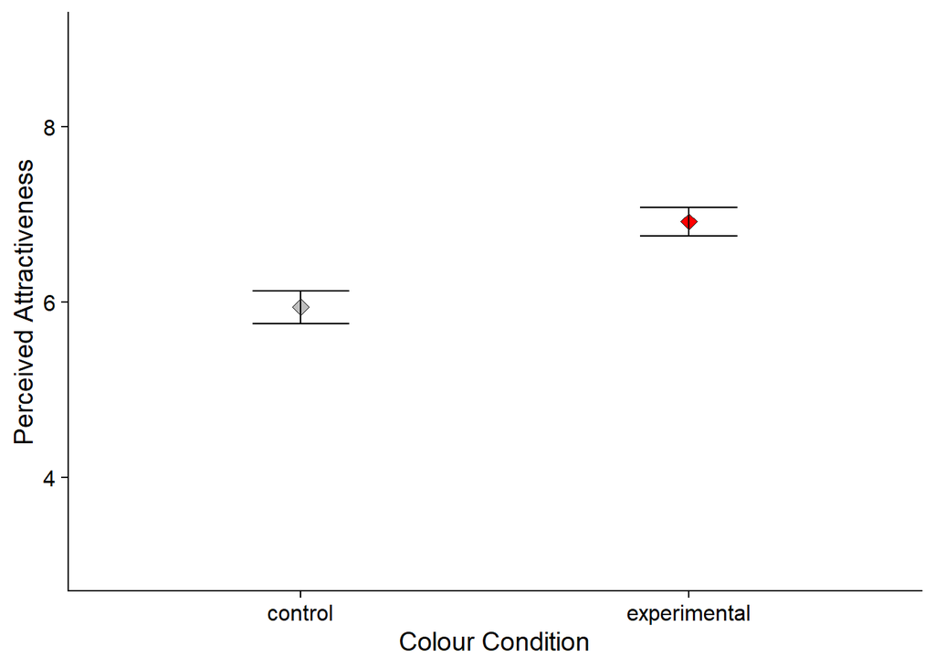

**Figure 2. shows the mean perceived rating scores between the two colour conditions, SEM +/-**

Figure 2. shows the mean response of perceived attraction in each condition. The x-axis depicts the two conditions, with the grey plot over control condition representing the attraction ratings for the white-bordered picture and the red plot over experimental condition representing the red-bordered picture. The y-axis depicts the mean rating of perceived attractiveness

We wanted to know whether there was a relationship between the colour red and ratings of attraction. Therefore we conducted an independent-measures *t*-test with the predictor of colour and perceived attractiveness as the outcome. The analysis indicated that participants in the red (experimental) condition gave higher mean ratings of perceived attractiveness to the target man (*M* = 6.92), compared with participants in the white condition (*M* = 5.94). The difference between the mean attractiveness ratings in the red vs white colour groups was significant, suggesting a positive relationship between colour and perceived attraction (*M*<sub>diff</sub> = 0.97, 95% CI [-0.72, -1.22], *t* (122) = -7.65, *p* = <.001`). This means that by changing the colour associated with the photographed male from white to red, ratings of perceived attraction increased.

# Discussion

In this experiment, our aim was to investigate the question: Is the red effect on attraction replicable and does the effect truly exist? Our findings show that when the colour red is associated with a pictured man, women rate the man as being more attractive. This supports our initial hypothesis that colour influences attraction, with the significant findings allowing us to reject the null hypothesis that red has no effect on ratings of attraction and accept the alternative hypothesis that the red effect influences ratings of attraction.

This replication of Elliot et al’s original study suggests that the red effect they presented does in fact exist (Elliot et al., 2010). We collected similar results to the original study, and they showed the same pattern of attraction ratings, with ratings in the red condition being higher than those in the white condition. This is supported by further research into the effects of the colour red on attraction such as a study by Roberts, Owen and Havlicek (2010) who investigated the effect of colour on attraction with 6 different colours of t-shirt (Roberts et al., 2010). They found that for females rating a photographed male wearing different coloured t-shirts, the men wearing red were rated as most attractive, closely followed by black. In their second experiment, similar results were found, with the red wearing male being most highly rated for attractiveness by the female participants. These findings support Elliot et al’s original findings (2010) and the findings in our replication study, suggesting the red effect does occur.

However, Roberts et al (2010) used a within-subjects design, which may have caused participant to become aware of the experiment’s purpose. This would have been an issue as demand characteristics may have occurred, making the results unreliable. Furthermore, other research into the red effect has found insignificant results, causing researchers to question whether the effect really exist (Hesslinger et al., 2015; Peperkoorn et al., 2016). Hesslinger, Goldbach and Carbon (2015) conducted an experiment repeating Elliot et al’s original experiment 1 (2010) and found insignificant statistical results, even after adjusting for gender.

The original study that we have replicated has also been criticized for publication bias by Francis (2013) who applied Ioannidis and Trikalinos’s (2007b) test to the results and found statistical evidence of publication bias for the relationship reported between red and attractiveness (Trikalinos, 2007, as cited in, Francis, 2013). In response to this criticism, Elliot and Maier (2013), referred to Trikalinos et al’s original paper which described the test as being an “exploratory test” and one that should be used with caution, suggesting that Francis’ analysis may not be valid (Elliot & Maier, 2013).

However, in their response, Elliot et al (2013) also conducted a replication of their initial experiment 3 which investigated perceived attractiveness and perceived likability. Although women still rated attraction as higher in the red condition, the results were insignificant, suggesting further research with larger samples is required, due to the disagreement in significance of the red effect between studies.

One strength of the present study is that it has produced extremely similar results to Elliot et al’s original study (2010), providing supporting evidence for the red effect and increasing the original study’s reliability. Furthermore, this suggests the results can be generalised to a larger population, as the results are significant to the same level as the original results, meaning that there is higher validity in the results.

One criticism of our experiment is that it lacks ecological validity, as colour being associated to a picture is unlikely to occur in everyday life. However, research has shown that adding redness to a man’s face leads to higher ratings of attractiveness (Re et al., 2011) and when women are asked to change the colour of a man’s face to make them more attractive, they tend to add more red to the face (Stephen & Mckeegan, 2010). These studies show a red effect occurring in a more natural setting, providing evidence that the effect does occur. This effect is also seen in non-human primates as demonstrated by Waitt et al, who found that female rhesus macaques had a greater preference to males with enhanced facial redness (Waitt et al., 2003). This further supports the suggestion that redness has an effect on attraction (or mating preference in non-human primates).

Further study into facial redness would be required to investigate the direct effect of redness on ratings of attraction. This could include looking at different causes of facial redness and the different effects it has on attraction ratings, for instance, redness from embarrassment may be rated differently to redness from exercise. Further replications of studies such as Elliot et al’s (2010) and Robert et al’s (2010) will also be necessary to determine the true significance of the red effect.

In conclusion, our replication of Elliot et al’s original study (2010) shows a similar pattern of results and therefore supports their theory of the red effect, showing how red can be an influence over women’s perceived attraction to men. Varying results between different research into this topic means further research will be required to determine the true relevance of the red effect on attraction, creating an interesting area of future research within the field of social psychology.

# References

Elliot, A. J., & Maier, M. A. (2013). The red-attractiveness effect, applying the Ioannidis and Trikalinos (2007b) test, and the broader scientific context: A reply to Francis (2013). *Journal of Experimental Psychology: General, 142*(1), 297–300. http://dx.doi.org/10.1037/a0029592

Elliot, A. J., Niesta Kayser, D., Greitemeyer, T., Lichtenfeld, S., Gramzow, R. H., Maier, M. A., & Liu, H. (2010). Red, rank, and romance in women viewing men. *Journal of Experimental Psychology: General, 139*(3), 399–417. https://doi.org/10.1037/a0019689

Francis, G. (2013). Publication bias in “Red, rank, and romance in women viewing men,” by Elliot et al. (2010). *Journal of Experimental Psychology: General, 142*(1), 292–296. APA PsycArticles®. https://doi.org/10.1037/a0027923

Hesslinger, V. M., Goldbach, L., & Carbon, C.-C. (2015). Men in red: A reexamination of the red-attractiveness effect. *Psychonomic Bulletin & Review, 22*(4), 1142–1148. https://doi.org/10.3758/s13423-015-0866-8

Peperkoorn, L. S., Roberts, S. C., & Pollet, T. V. (2016). Revisiting the Red Effect on Attractiveness and Sexual Receptivity: No Effect of the Color Red on Human Mate Preferences. *Evolutionary Psychology, 14*(4), 1474704916673841. https://doi.org/10.1177/1474704916673841

Re, D. E., Whitehead, R. D., Xiao, D., & Perrett, D. I. (2011). Oxygenated-Blood Colour Change Thresholds for Perceived Facial Redness, Health, and Attractiveness (Perceptual Thresholds for Facial Redness). *PLoS ONE, 6*(3), e17859. https://doi.org/10.1371/journal.pone.0017859

Roberts, S. C., Owen, R. C., & Havlicek, J. (2010). Distinguishing between Perceiver and Wearer Effects in Clothing Color-Associated Attributions. *Evolutionary Psychology, 8*(3), 147470491000800320. https://doi.org/10.1177/147470491000800304

Stephen, I. D., & Mckeegan, A. M. (2010). Lip Colour Affects Perceived Sex Typicality and Attractiveness of Human Faces. *Perception, 39*(8), 1104–1110. https://doi.org/10.1068/p6730

Trikalinos, T. (2007). An exploratory test for an excess of significant findings. *Clinical Trials, 4*(3), 245–253. https://doi.org/10.1177/1740774507079441

Waitt, C., Little, A. C., Wolfensohn, S., Honess, P., Brown, A. P., Buchanan-Smith, H. M., & Perrett, D. I. (2003). Evidence from rhesus macaques suggests that male coloration plays a role in female primate mate choice. *Proceedings of the Royal Society of London. Series B: Biological Sciences, 270*(suppl_2). https://doi.org/10.1098/rsbl.2003.0065